# Notebook

```python
from pyspark.sql import SparkSession
import pyspark.sql.functions as F
```

```python
spark = SparkSession.builder.config("spark.sql.streaming.schemaInference", True).getOrCreate()

stream = spark.\
    readStream.\
    format("ws").\
    option("schema", "ticker").\
    load() # we need to pass `option("schema", "ticker")` to get correct channel subscribed

query = stream.select("side", "product_id", "last_size", "best_bid", "best_ask", "time").\
    writeStream.\
    format("console").\
    outputMode("append").\
    option("truncate", "false").\
    start()

query.awaitTermination(10) # Let's wait for 10 seconds.
query.stop() # Let's stop the query
stream.printSchema()
#spark.stop() # And stop the whole session
```

```
root
 |-- type: string (nullable = false)
 |-- trade_id: long (nullable = false)
 |-- sequence: long (nullable = false)
 |-- time: timestamp (nullable = false)
 |-- product_id: string (nullable = false)
 |-- price: double (nullable = false)
 |-- side: string (nullable = false)
 |-- last_size: double (nullable = false)
 |-- best_bid: double (nullable = false)
 |-- best_ask: double (nullable = false)
```

Uruchamiająć `stream.start()` uruchamiamy w osobnym demonie websocket który streamuje wyniki. Jeżeli wystąpi jakiś błąd po stronie front-endu (np. błąd parsowania kolejnej linijki Pythona) fakt ten nie zostanie zgłoszony do sparka i socket pozostanie otwarty! Należy pamiętać, by zamykać stream za każdym razem używająć metody `stop()` (w powyższym przykładzie `query.stop()`). W przypadku utracenia referencji do zapytania, należy zastopować całą sesję również metodą `stop()` (w powyższym przykładzie `spark.stop()`)

```python
# Panic button - press only if you messed up opening new websocket and lost reference to it

query.stop()
spark.stop()
```

# Zadanie 1

**Analiza strumienia danych CoinBase (3p)**. Napisz zapytanie, które wypisuje średnią wartość wybranego parametru (np. `price`) w przesuwnych oknach czasowych względem czasu transakcji (kolumna `time`), grupując po relacji wymiany (z jakiej waluty na jaką walutę - kolumna `product_id`).

```python
from pyspark.sql.functions import col, window, avg

window_duration = "10 minutes"  # Total window size
slide_duration = "5 minutes"   # Sliding interval step size

# Transform the stream: Calculate average price in sliding windows grouped by product_id
result_df = stream.groupBy(
    window(col("time"), window_duration, slide_duration),  # Sliding time window
    col("product_id")  # Group by exchange relationship
).agg(
    avg("price").alias("avg_price")  # Average the `price` column
)

query = result_df.writeStream.format("console").outputMode("update").option("truncate", "false").start()

query.awaitTermination(20)  # Wait for 10 seconds to display results
query.stop()
```

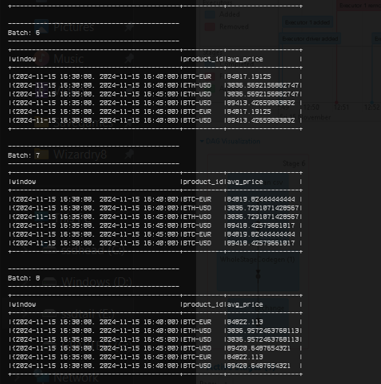

# Zadanie 2

**Watermarking i dane opóźnione (3p).** Zmodyfikuj zapytanie z zadania 1 tak, aby zademonstować mechanizm znaków wodnych (watermarks) i obsługi danych opóźnionych. W konsoli powinno być widać, że aktualizują się odpowiednie wiersze tabeli wynikowej (tryb update), w szczególności aktualizacja wcześniejszych okien czasowych po przybyciu danych opóźnionych. **Do rozwiązania tego zadania proszę dołączyć przykładowy output i jego opis wyjaśniający na konkretnym przykładzie działanie znaku wodnego i danych opóźnionych**.

Do ćwiczenia można wykorzystać skrypt w katalogu `/mock` napisany w [Scala-cli](https://scala-cli.virtuslab.org), który posłuży jako kontrolowane źródło danych CoinBase przez Websocket.

Skrypt można uruchomić wykorzystując Docker:

```
make image
make run
```

Spowoduje to utworzenie websocketowego serwera pod adresem `ws://mock:8025`

Po uruchomieniu serwera należy wykonać poniższą komórkę, w której zapytanie czyta dane z utworzonego websocketa. Skrypt wysyła przykładowe wiadomości w formacie CoinBase co 10 sekund:

- W pierwszej serii wysyłane wiadomości o znacznikach czasowych 0s, 14s, 7s
- W drugiej serii wysyłane są wiadomości o znacznikach czasowych 15s, 8s, 21s
- W trzeciej serii wysyłane są wiadomości o znacznikach czasowych 4s, 17s

Dla tych danych można ustawić okno czasowe na interwał 10 sekund. Skrypt można też zmodyfikować, tak aby wysyłał inne dane.

```python
from pyspark.sql import SparkSession
from pyspark.sql.functions import col, window, avg

spark = SparkSession.builder.config("spark.sql.streaming.schemaInference", True).config("spark.sql.streaming.forceDeleteTempCheckpointLocation", True).getOrCreate()
stream = spark.readStream.format("ws").option("schema", "ticker").option("url", "ws://mock:8025").load()

# Define the parameters for window and watermark
window_duration = "10 seconds"
watermark_delay = "5 seconds"

# Process the data: apply watermark and aggregate
result_df = stream \
    .withWatermark("time", watermark_delay) \
    .groupBy(
        window(col("time"), window_duration),  # Fixed-size window of 10 seconds
        col("product_id")  # Group by product_id
    ) \
    .agg(
        avg("price").alias("avg_price")  # Calculate average price
    )

# Output the results to the console
query = result_df.writeStream \
    .format("console") \
    .outputMode("update") \
    .option("truncate", "false") \
    .start()

# Allow the query to run for 30 seconds
query.awaitTermination(30)
query.stop()
```

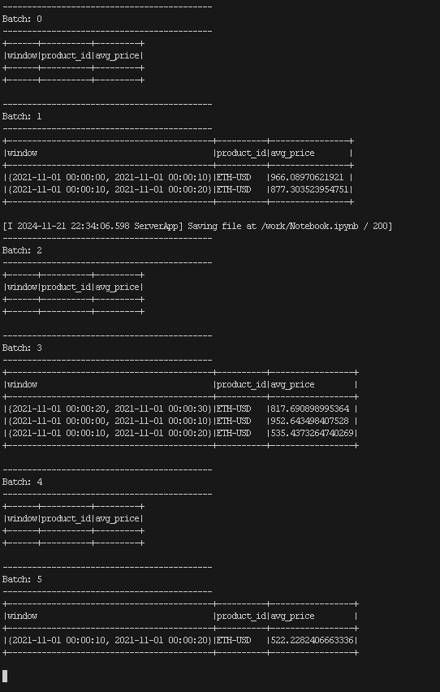

- W pierwszej serii wysyłane wiadomości o znacznikach czasowych 0s, 14s, 7s
- W drugiej serii wysyłane są wiadomości o znacznikach czasowych 15s, 8s, 21s - 8 jeszcze wlaczony, bo 5 sekund delaylapie go w tej grupie
- W trzeciej serii wysyłane są wiadomości o znacznikach czasowych 4s, 17s - 4 jest zignorowane bo przekroczony delay 5 sekund

# Zadanie 3

**Łączenie strumieni (3p)**. Korzystając z łączenia strumieni połącz dane z kanału `ticker` (transakcje kupna `side="buy"`) razem z danymi o transakcjach napływających co sekundę `heartbeat` korzystając z `trade_id` i odpowiedniego id w kanale heartbeat. Wypisz połączony strumień danych.

Na moment tworzenia zadania 15.11.2023 kanał `heartbeat` zwraca błędne dane o dacie (np. `1970-01-04 13:53:57.645339`). Połączenie z kanałem `ticker` pozwala uzyskać poprawne informacje. Cóż za wspaniałe zastosowanie joina!

```python
query = stream.select("time").writeStream.format("console").outputMode("append").start()
query.awaitTermination(10)  # Let the stream run for 10 seconds
query.stop()
```

```python
heartbeat_stream_prefixed.printSchema()
```

```
root
 |-- heartbeat_type: string (nullable = false)
 |-- heartbeat_sequence: long (nullable = false)
 |-- heartbeat_last_trade_id: long (nullable = false)
 |-- heartbeat_product_id: string (nullable = false)
 |-- heartbeat_time: timestamp (nullable = false)
```

```python
from pyspark.sql import SparkSession
from pyspark.sql.functions import col, window


spark = SparkSession.\
    builder.\
    config("spark.sql.streaming.schemaInference", True).\
    config("spark.sql.streaming.forceDeleteTempCheckpointLocation", True).\
    getOrCreate()

stream = spark.\
    readStream.\
    format("ws").\
    option("schema", "ticker").\
    load()


# Filter for buy-side transactions
ticker_buy_stream = stream.filter(col("side") == "buy")

# Read `heartbeat` stream
heartbeat_stream = spark.readStream.format("ws").option("schema", "heartbeat").load()

# Define join window size
join_window_duration = "10 seconds"  # Join window size

# Add prefix 'ticker.' to all columns in ticker_buy_stream
ticker_buy_stream_prefixed = ticker_buy_stream.select(
    [col(c).alias(f"ticker_{c}") for c in ticker_buy_stream.columns]
)

# Add prefix 'heartbeat.' to all columns in heartbeat_stream
heartbeat_stream_prefixed = heartbeat_stream.select(
    [col(c).alias(f"heartbeat_{c}") for c in heartbeat_stream.columns]
)

# Perform the join
joined_stream = ticker_buy_stream_prefixed.join(
    heartbeat_stream_prefixed,
    on=col("ticker_trade_id") == col("heartbeat_last_trade_id"),  # Join on trade_id
    how="inner"  # Inner join
)
# Output joined stream to console
query = joined_stream.writeStream.format("console").outputMode("append").option("truncate", "false").start()

# Wait for termination
query.awaitTermination(1900)
query.stop()
```

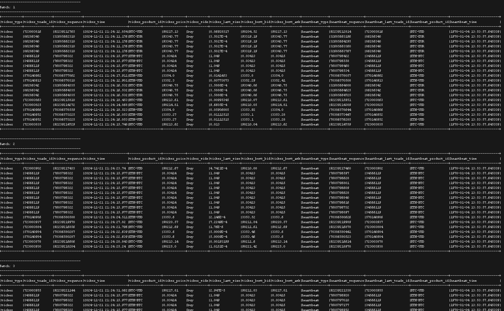